# Análisis estadístico sobre casos confirmados de Covid-19 en México

Daniel Alejandro Cruz Pérez

8/5/2020

# Última actualización: 11/5/2020

# Fecha de últimos datos capturados: 10/5/2020

## Introducción

Dado al alarmante número de casos positivos a **COVID-19** en conjunto al elevado número de noticias y cifras falsas sobre el tema, me he dado a la tarea de realizar un análisis estadístico sobre las bases de datos oficiales publicadas por la Secretaría de Salud de México con la única finalidad de facilitar la comprensión de datos a la población.

Dichos datos pueden ser obtenidos del sitio de Datos Abierto México: https://datos.gob.mx/busca/dataset/informacion-referente-a-casos-covid-19-en-mexico

## Metadatos

| Fuente | https…www.gob.mx.salud |
| --- | --- |
| Email del publicador | hector.paredes@salud.gob.mx |
| Frecuencia | R/P1D |
| GUID | informacion-referente-a-casos-covid-19-en-mexico |
| Idioma | es |
| Nombre del publicador | SALUD |
| Publicado | 2020-04-14T00:28:50Z |
| Tipo del publicador | Subdirector de Notificación y Registros Epidemiológicos. |

## Notas adicionales

**El objetivo del presente reporte es meramente informativo y sin fines de lucro, los datos en ningún momento han sido modificados.**

## Presentación de resultados

### Pacientes positivos a COVID-19: **35,022**

Los estados que presentan un menor número de contagios, de menor a mayor son:

1. Colima.
2. Durango.
3. Zacatecas.

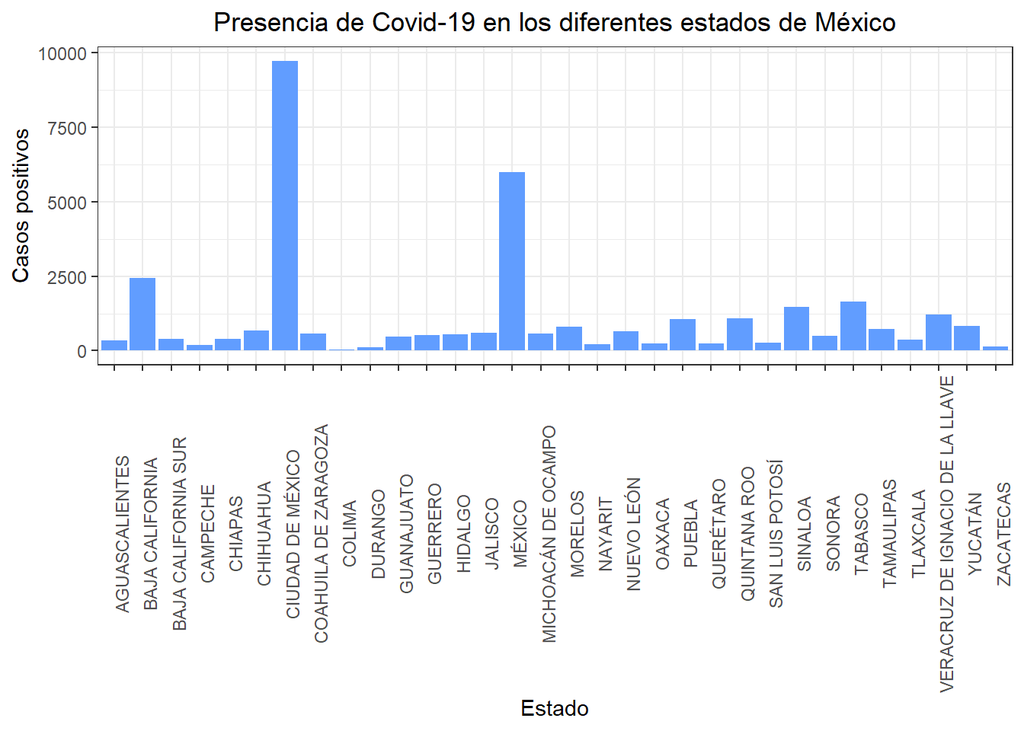

Gracias a la siguiente gráfica podemos interpretar que se ha presentado un mayor número de contagios en hombres.

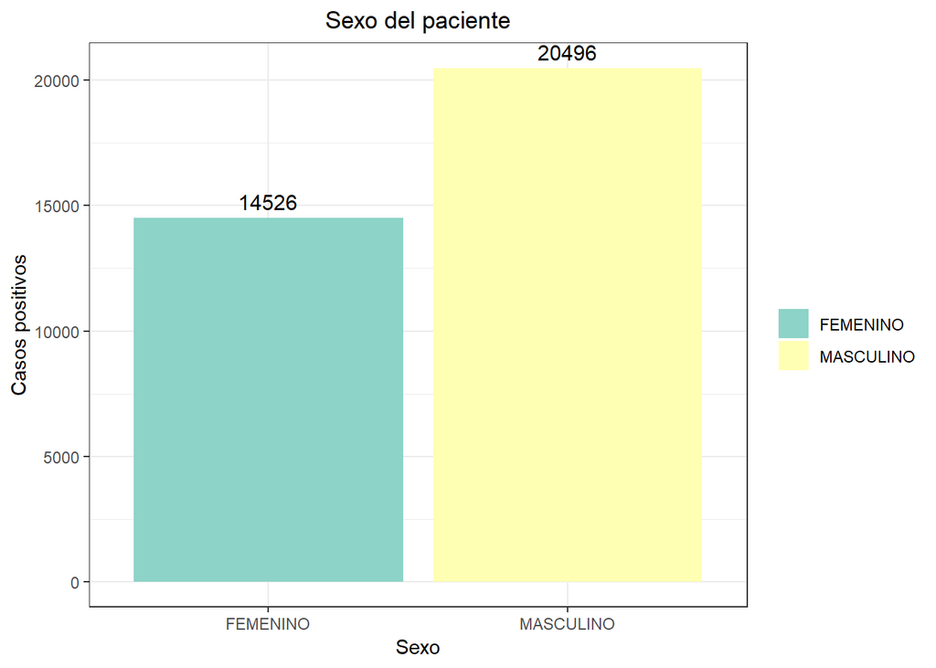

Las instituciones de salud que mayor apoyo han brindado han sido:

1. SSA.
2. IMSS.
3. ISSSTE (teniendo una menor presencia que los anteriores).

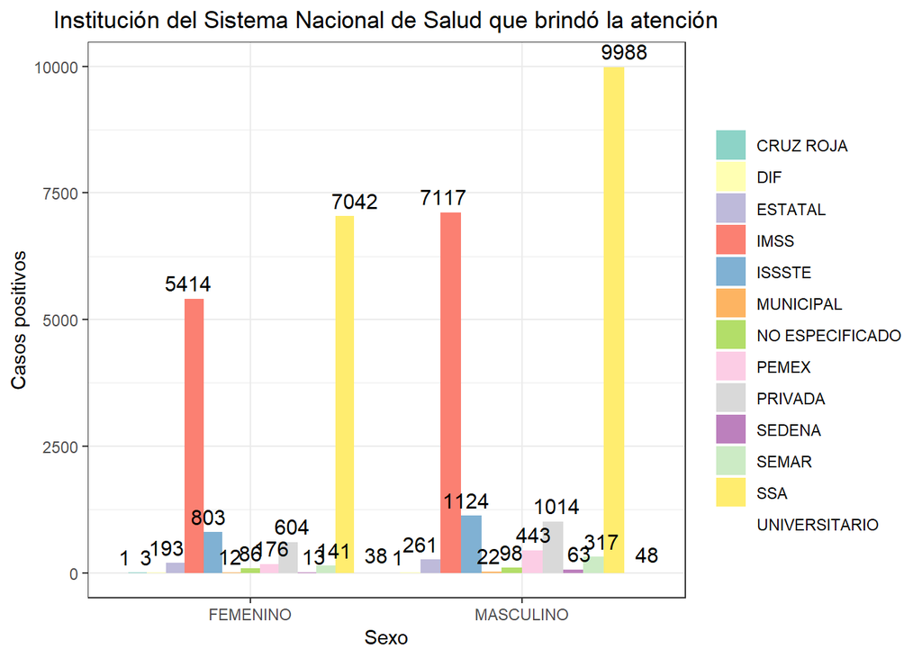

La vigilancia centinela se realiza a través del sistema de unidades de salud monitoras de enfermedades respiratorias (USMER). Las USMER incluyen unidades médicas del primer, segundo o tercer nivel de atención y también participan como USMER las unidades de tercer nivel que por sus características contribuyen a ampliar el panorama de información epidemiológica, entre ellas las que cuenten con especialidad de neumología, infectología o pediatría.

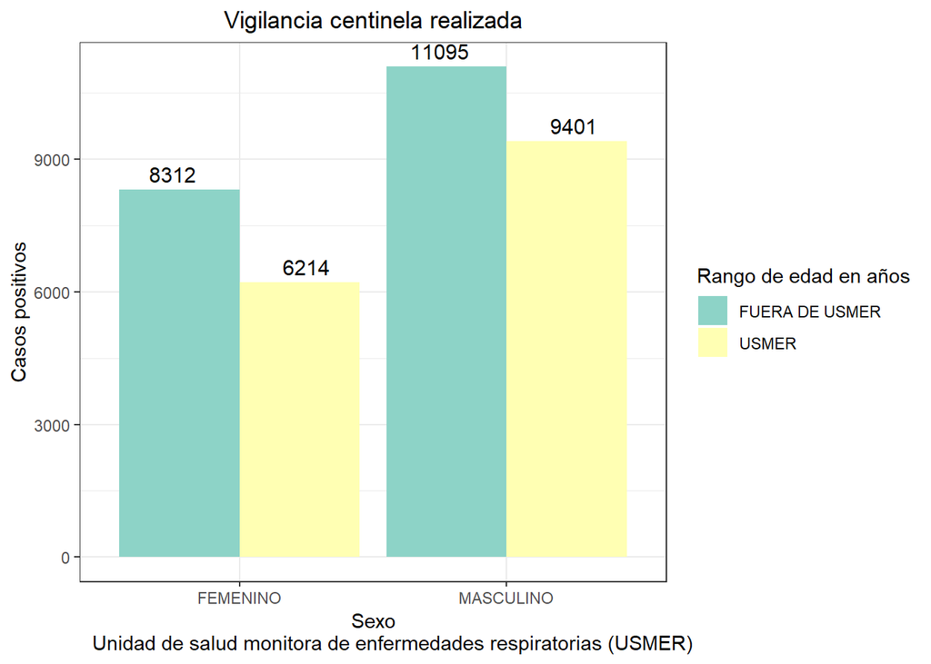

La gráfica que representa el rango de edad nos demuestra que de los pacientes de 11 a 20 años a los de 21 a 30 años hay un considerable aumento del 807% en hombres y del 712% en mujeres, podemos asumir que se debe a que los jóvenes de estas edades por lo general son estudiantes y/o trabajadores que suelen moverse comunmente en transportes públicos, lo que genera un potente riesgo de contagio.

Otro punto interesante es el siguiente aumento de personas con rangos de edades de 31 a 60 años, representando un aumento con respecto a los jóvenes, del 181% en hombres y del 165% en mujeres, además de representar un decremento con respecto a las personas de la tercera edad del 231% en hombres y del 208% en mujeres.

Podemos asumir que dichos incrementos se deben a que muchos jóvenes han podido resguardarse estudiando y/o trabajando desde casa a diferencia de muchos adultos que deben trabajar en planta.

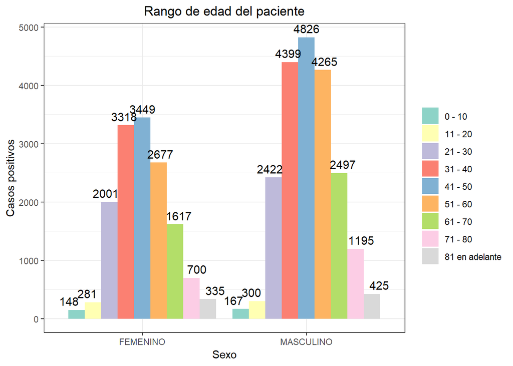

## Las siguientes gráficas presentan complicaciones médicas que presentaron los pacientes.

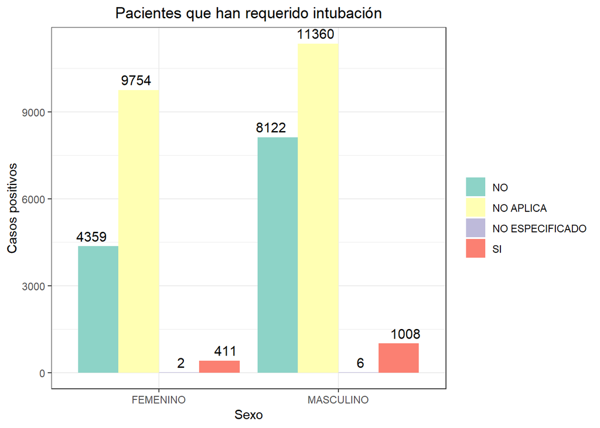

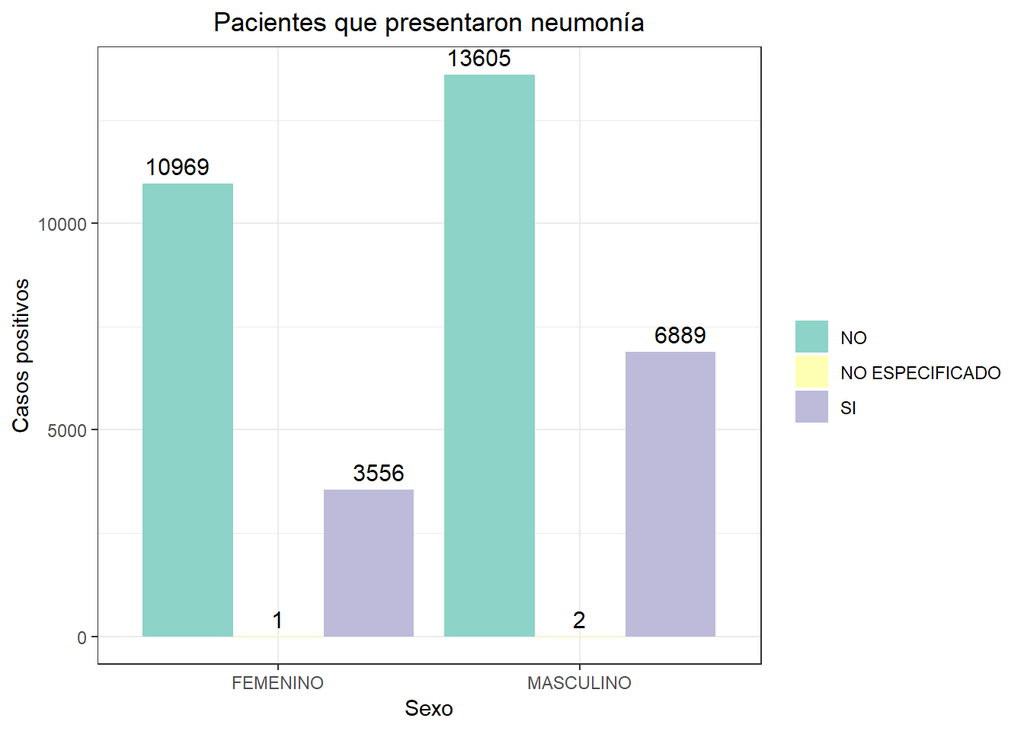

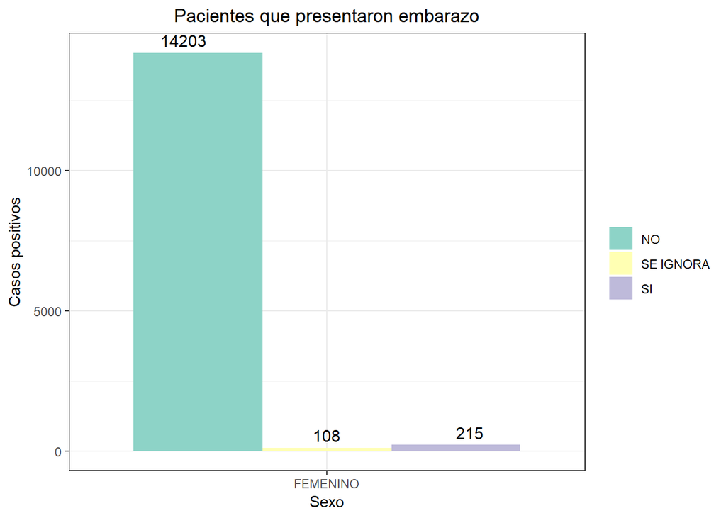

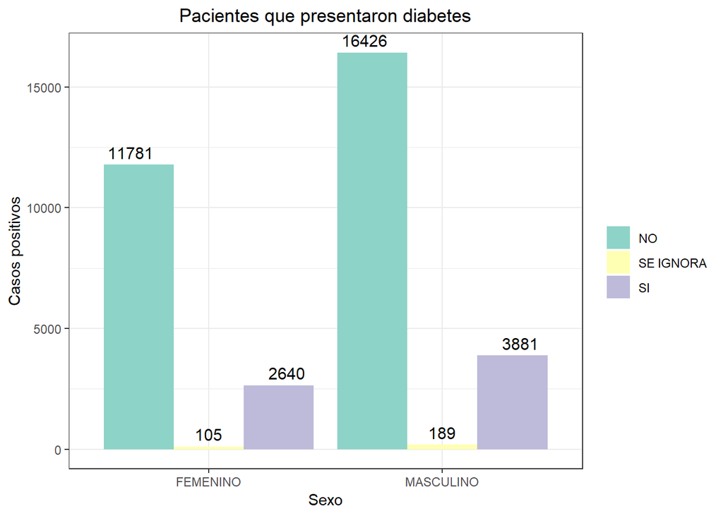

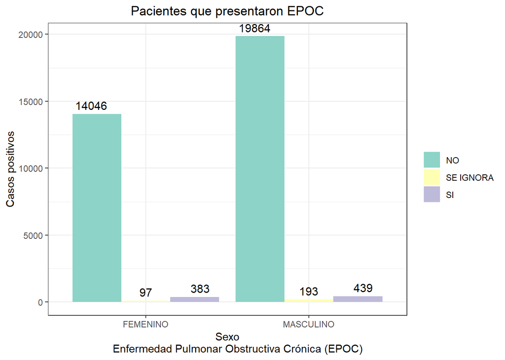

**NOTA** Se puede observar que en mujeres hay mayor probabilidad de presentar asma que en hombres.

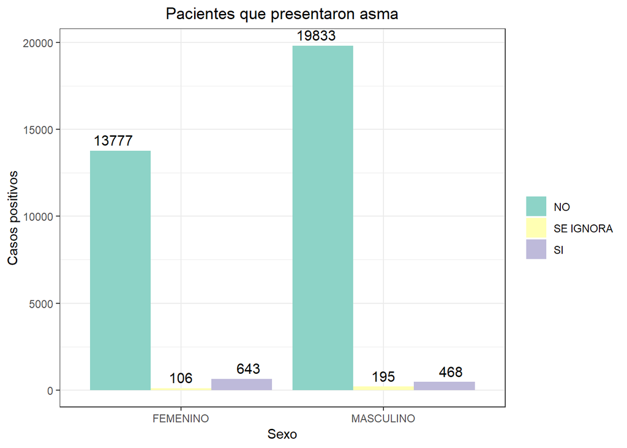

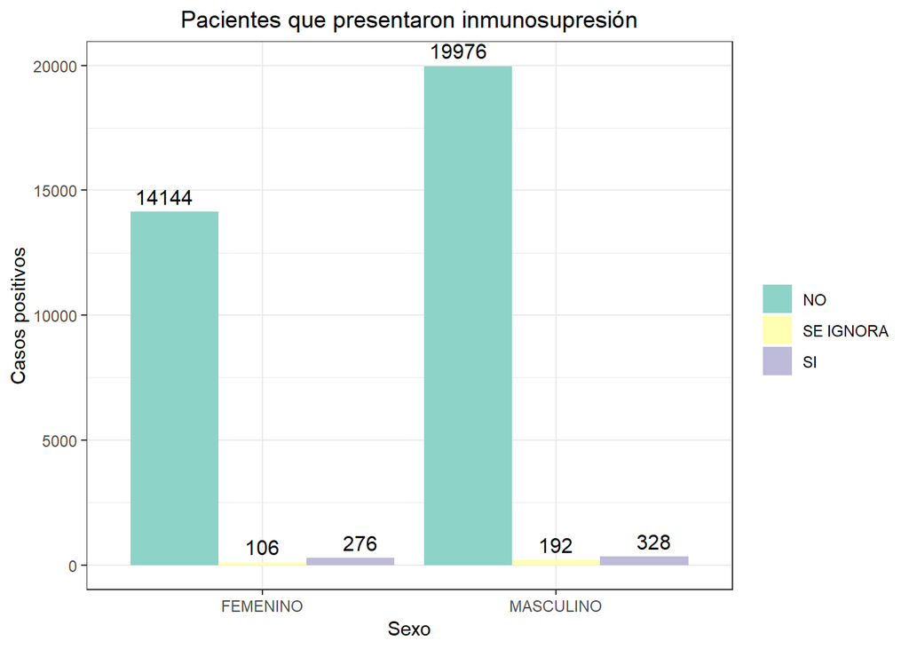

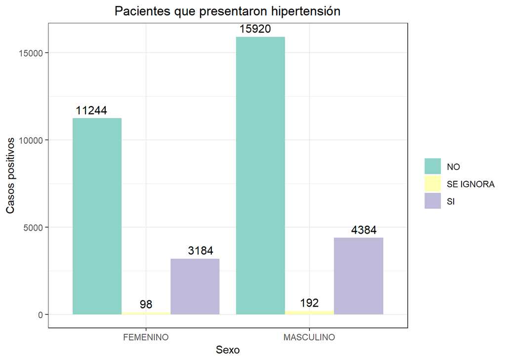

**NOTA** Se puede observar que en mujeres hay mayor probabilidad de presentar otras complicaciones médicas diagnosticadas.

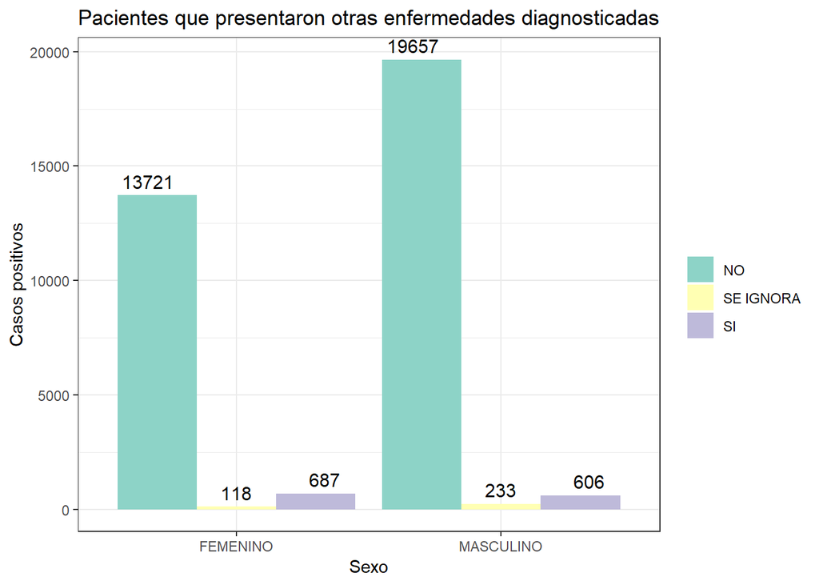

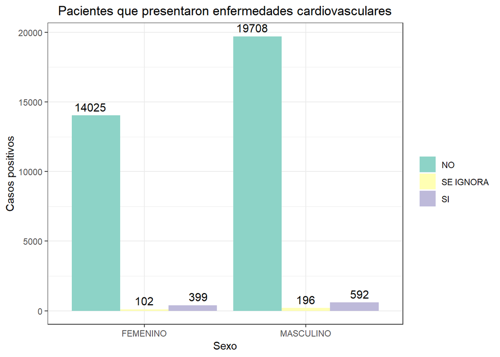

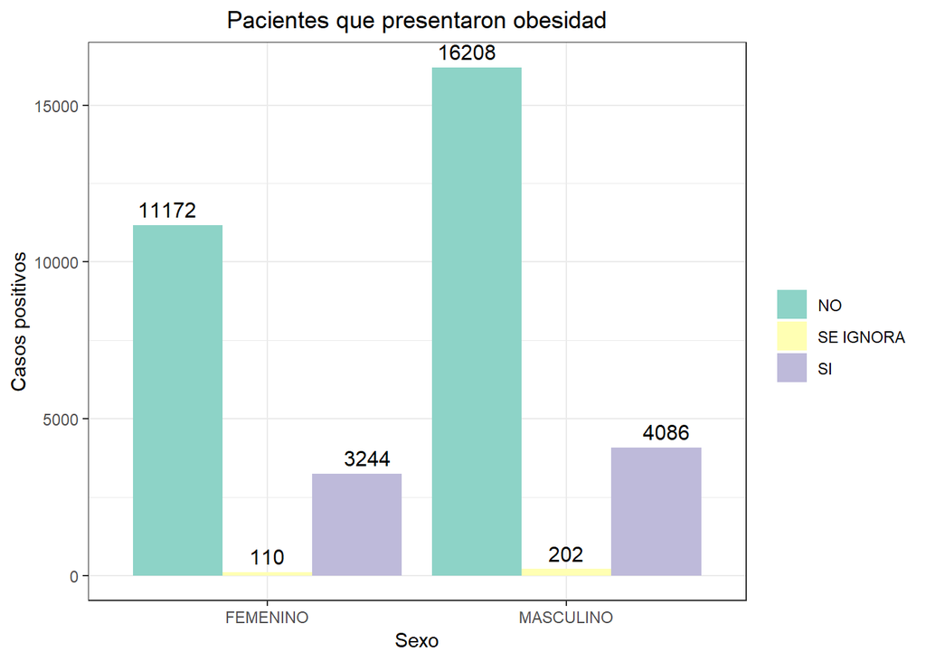

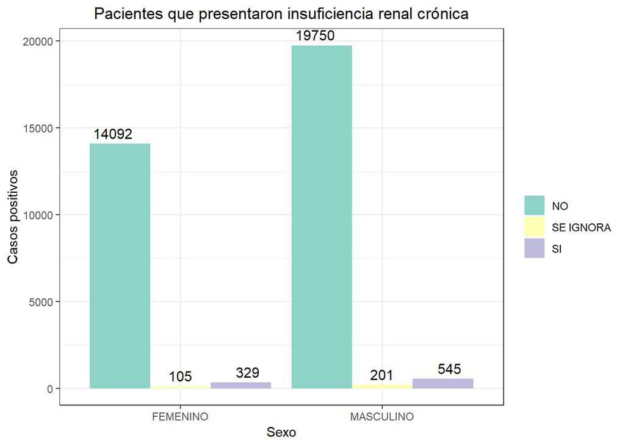

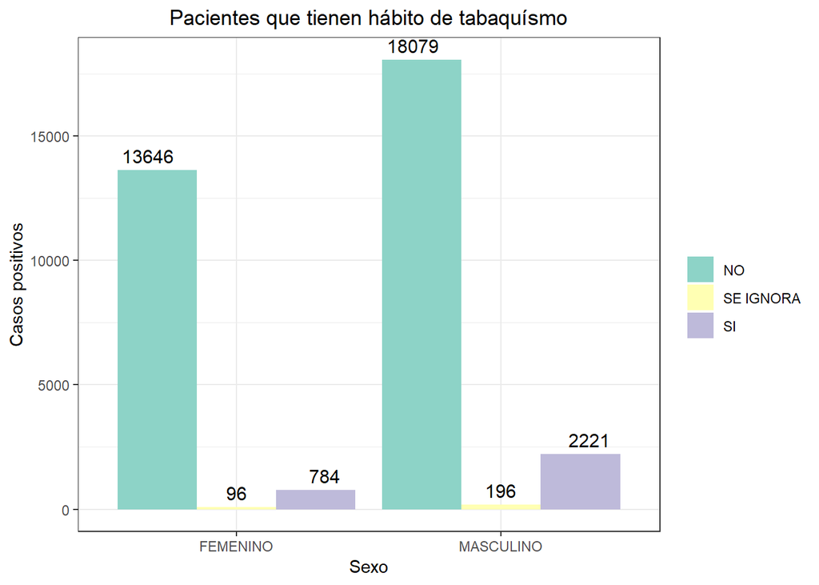

**NOTA IMPORTANTE**

Podemos observar que en mujeres presentarón un mayor número de contagios por interactuar con otras personas infectadas a diferencia de las mujeres que afirmaron no haber tenido contacto con personas infectadas.

En caso de los hombres, es más notable la diferencia de quienes afirmaron no haber tenido contacto con personas infectadas a diferencia de quienes afirmaron haberlo tenido.

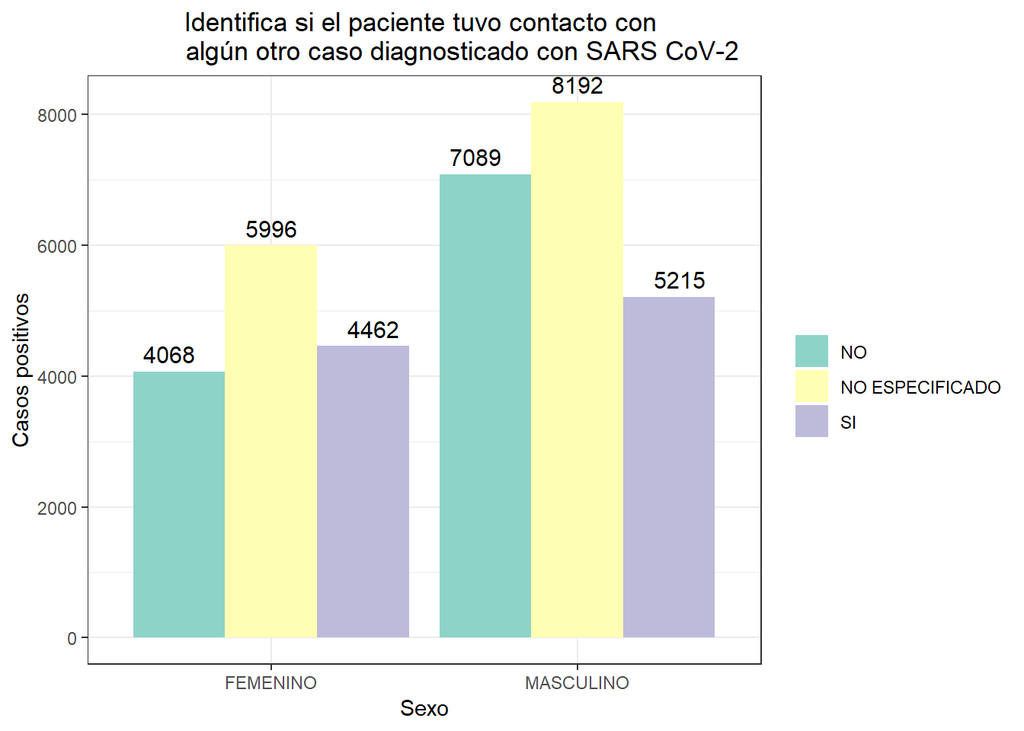

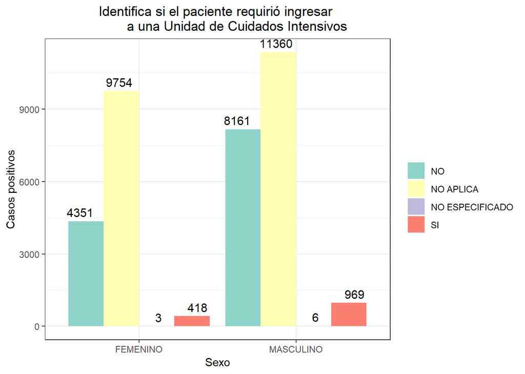

La siguiente gráfica presenta el número de pacientes registrados como positivos por día, la baja en los últimos números puede deberse no sólo a que haya menos infecciones, sino también al tiempo que tardan en publicar los nuevos resultados.

Podemos observar que a partir de marzo (Fecha en que inicia la cuarentena) los números han ido subiendo de una manera significativa, siendo a mediados de abril el pico más alto de contagios por día.

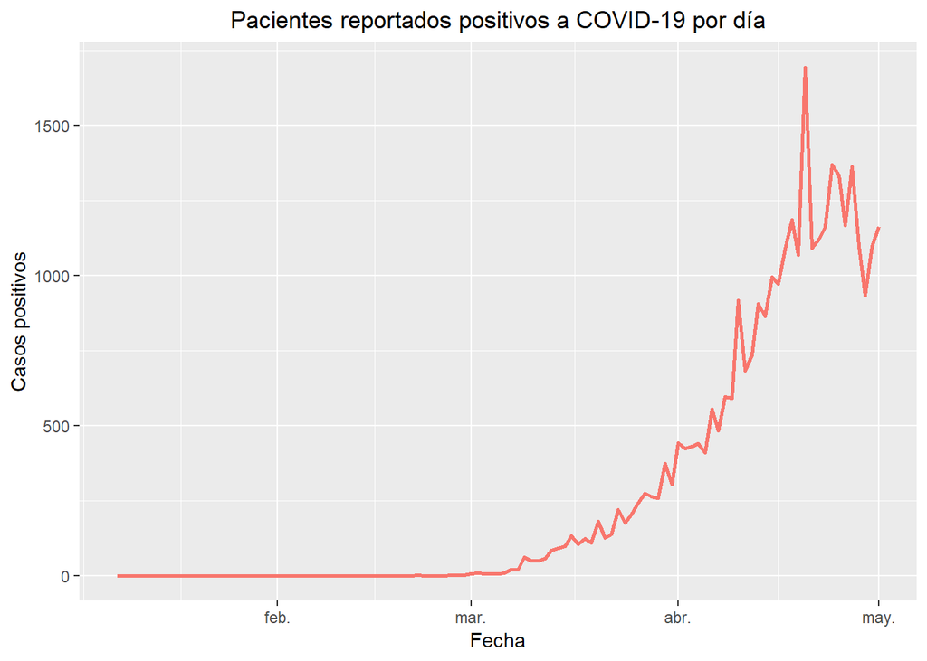

La siguiente gráfica representa la cantidad de personas que han fallecido por día debido a COVID-19. Podemos observar que el número de muertes va en aumento.

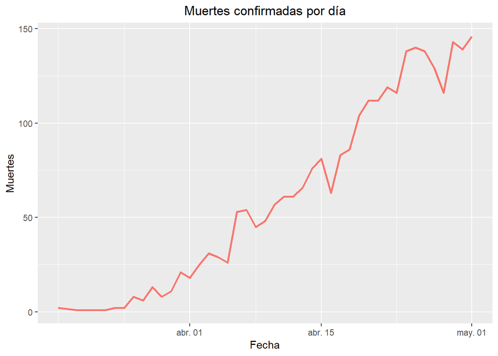

De la siguiente gráfica podemos interpretar que la enfermedad es más letal en personas de 41 a 70 años, siendo estos quienes mayor número de bajas presentan.

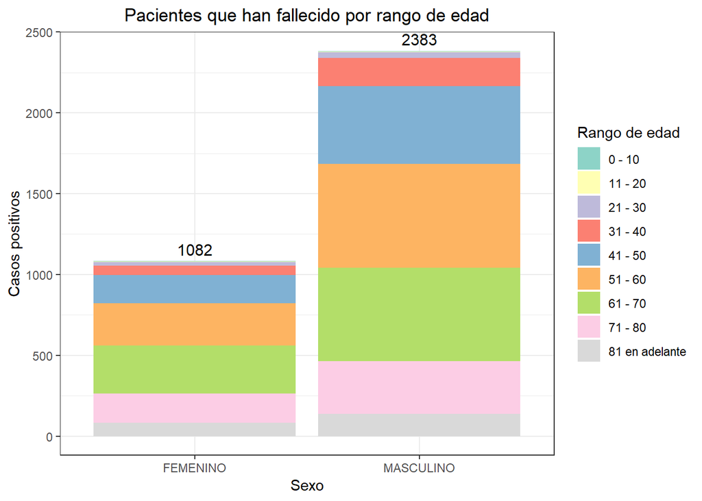

## Reconocimiento de patrones en personas infectadas

Se realizó una metodología de CLARA (Clustering Large Applications) basada en K-MEANS para agrupar personas que compartan características con la finalidad de encontrar que patrones siguen y como se diefencian unos grupos de otros.

(Para mayor información del aloritmo K-MEANS anexo el siguiente artículo de públicado por la universidad de Stanford: https://stanford.edu/~cpiech/cs221/handouts/kmeans.html)

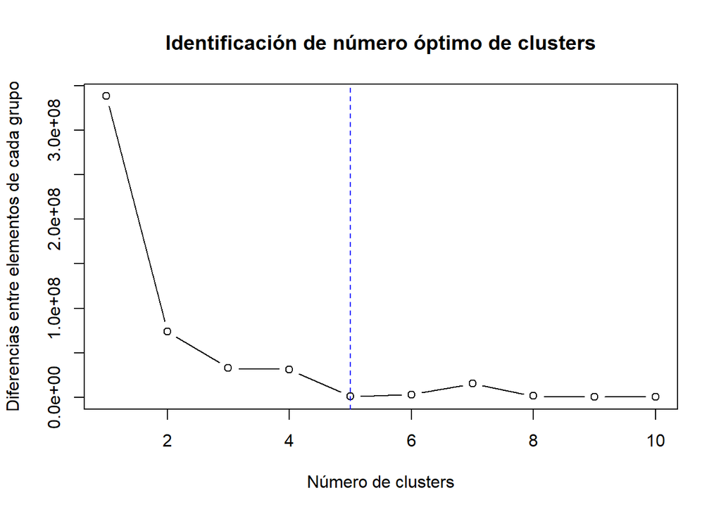

La siguiente gráfica representa la separación de pacientes por grupos.

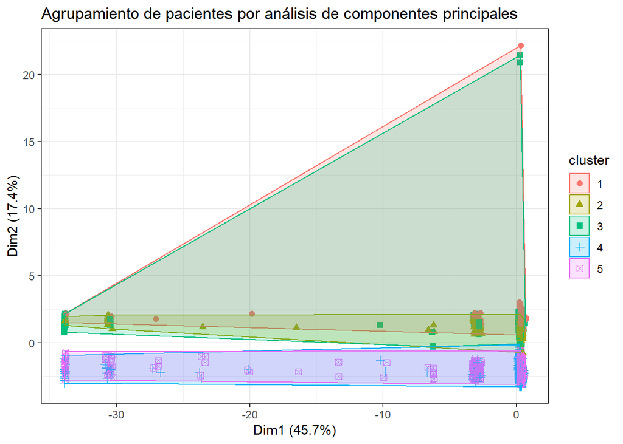

La siguiente tabla describe los patrones presentados

|  | Cluster 1 | Cluster 2 | Cluster 3 | Cluster 4 | Cluster 5 |
| --- | --- | --- | --- | --- | --- |
| Origen | FUERA DE USMER | FUERA DE USMER | FUERA DE USMER | USMER | USMER |
| Institución que brindó atención | SSA | SSA | IMSS | IMSS | SSA |
| Sexo | FEMENINO | MASCULINO | MASCULINO | MASCULINO | MASCULINO |
| Tipo de paciente | AMBULATORIO | AMBULATORIO | AMBULATORIO | HOSPITALIZADO | HOSPITALIZADO |
| Fue intubado? | NO APLICA | NO APLICA | NO APLICA | NO | NO |
| Presentó neumonía? | NO | NO | NO | SI | SI |
| Rango de edad | 41 - 50 | 41 - 50 | 31 - 40 | 51 - 60 | 51 - 60 |
| Presentó un embarazo? | NO | NO APLICA | NO APLICA | NO APLICA | NO APLICA |
| Presentó diabetes? | NO | NO | NO | NO | NO |
| Presentó EPOC? | NO | NO | NO | NO | NO |
| Presentó ASMA? | NO | NO | NO | NO | NO |
| Presentó Inmunosupresión? | NO | NO | NO | NO | NO |
| Presentó hipertensión | NO | NO | NO | NO | NO |
| Presentó otra enfermedad? | NO | NO | NO | NO | NO |
| Presentó problemas cardiovasculares? | NO | NO | NO | NO | NO |
| Presentó obesidad? | NO | NO | NO | NO | NO |
| Presentó insuficiencia renal? | NO | NO | NO | NO | NO |
| Presentó hábito de tabaquismo? | NO | NO | NO | NO | NO |
| Tuvo contacto con otro positivo? | SI | SI | NO ESPECIFICADO | NO ESPECIFICADO | NO |
| Requirió cuidados intensivos? | NO APLICA | NO APLICA | NO APLICA | NO | NO |